# GATHER

### '<AHREF=" " ' surrounds each source

### Define

Extract the source from the App Url using regex library to just give the source of the tweet, removing the Url for the app

### Code

```python
# Use re library with findall function and extract real source from tags > ...... <
df1['source'] = df1['source'].apply(lambda x: re.findall(r'>(.*)<', x)[0])
```

### Test

```python
# Check extracted correct information
df1['source'].value_counts()
```

```
Twitter for iPhone    1926
Twitter Web Client      28
TweetDeck               10
Name: source, dtype: int64
```

```python
df1.sample(10)
```

|  | tweet_id | timestamp | source | text | expanded_urls | rating_numerator | rating_denominator | name | favorites | retweets | ... | p1 | p1_conf | p1_dog | p2 | p2_conf | p2_dog | p3 | p3_conf | p3_dog | dog_type |
| --- | --- | --- | --- | --- | --- | --- | --- | --- | --- | --- | --- | --- | --- | --- | --- | --- | --- | --- | --- | --- | --- |
| 4278 | 814986499976527872 | 2016-12-31 00:08:17 | Twitter for iPhone | This is Cooper. Someone attacked him with a sharpie. Poor pupper. 11/10 nifty tongue slip tho ht... | https://twitter.com/dog_rates/status/814986499976527872/photo/1 | 11 | 10 | Cooper | 7505.0 | 1241.0 | ... | dalmatian | 0.999828 | True | boxer | 0.000068 | True | American_Staffordshire_terrier | 0.000034 | True | pupper |
| 1955 | 666057090499244032 | 2015-11-16 00:55:59 | Twitter for iPhone | My oh my. This is a rare blond Canadian terrier on wheels. Only $8.98. Rather docile. 9/10 very ... | https://twitter.com/dog_rates/status/666057090499244032/photo/1 | 9 | 10 | None | 262.0 | 116.0 | ... | shopping_cart | 0.962465 | False | shopping_basket | 0.014594 | False | golden_retriever | 0.007959 | True | None |
| 2688 | 748977405889503236 | 2016-07-01 20:31:43 | Twitter for iPhone | What jokester sent in a pic without a dog in it? This is not @rock_rates. This is @dog_rates. Th... | https://twitter.com/dog_rates/status/748977405889503236/photo/1 | 10 | 10 | None | 10386.0 | 3252.0 | ... | German_short-haired_pointer | 0.742216 | True | bluetick | 0.152810 | True | English_setter | 0.051835 | True | None |
| 3185 | 688385280030670848 | 2016-01-16 15:40:14 | Twitter for iPhone | This is Louis. He's takes top-notch selfies. 12/10 would snapchat with https://t.co/vz2DukO0th | https://twitter.com/dog_rates/status/688385280030670848/photo/1,https://twitter.com/dog_rates/st... | 12 | 10 | Louis | 8877.0 | 4253.0 | ... | golden_retriever | 0.900437 | True | cocker_spaniel | 0.022292 | True | sombrero | 0.014997 | False | None |
| 3633 | 671390180817915904 | 2015-11-30 18:07:47 | Twitter for iPhone | Striped dog here. Having fun playing on back. Sturdy paws. Looks like an organized Dalmatian. 7/... | https://twitter.com/dog_rates/status/671390180817915904/photo/1 | 7 | 10 | None | 1328.0 | 683.0 | ... | zebra | 0.997673 | False | tiger | 0.000837 | False | prairie_chicken | 0.000575 | False | None |
| 2177 | 838476387338051585 | 2017-03-05 19:48:43 | Twitter for iPhone | This is Stanley. Somehow he heard you tell him he's a good boy from all the way up there. 13/10 ... | https://twitter.com/dog_rates/status/838476387338051585/photo/1,https://twitter.com/dog_rates/st... | 13 | 10 | Stanley | 21718.0 | 4527.0 | ... | Great_Pyrenees | 0.997692 | True | kuvasz | 0.001001 | True | Newfoundland | 0.000405 | True | None |
| 2707 | 747219827526344708 | 2016-06-27 00:07:44 | Twitter for iPhone | This is Atticus. He's remaining calm but his costume looks terrified. 11/10 https://t.co/uT7QeZI34U | https://twitter.com/dog_rates/status/747219827526344708/photo/1,https://twitter.com/dog_rates/st... | 11 | 10 | Atticus | 5063.0 | 1491.0 | ... | Shetland_sheepdog | 0.548018 | True | marmot | 0.165503 | False | collie | 0.043003 | True | None |
| 47 | 881906580714921986 | 2017-07-03 16:04:48 | Twitter for iPhone | This is Rey. He's a Benebop Cumberfloof. 12/10 dangerously pettable https://t.co/503CgWbhxQ | https://twitter.com/dog_rates/status/881906580714921986/photo/1 | 12 | 10 | Rey | 22115.0 | 2964.0 | ... | Weimaraner | 0.291539 | True | Chesapeake_Bay_retriever | 0.278966 | True | koala | 0.127017 | False | None |
| 3789 | 668544745690562560 | 2015-11-22 21:41:02 | Twitter for iPhone | It is an honor to rate this pup. He is a Snorklhuahua from Amarillo. A true renaissance dog. Als... | https://twitter.com/dog_rates/status/668544745690562560/photo/1 | 10 | 10 | None | 472.0 | 207.0 | ... | bearskin | 0.427870 | False | bow | 0.258858 | False | panpipe | 0.021563 | False | None |
| 3241 | 684594889858887680 | 2016-01-06 04:38:35 | Twitter for iPhone | "FOR THE LAST TIME I DON'T WANNA PLAY TWISTER ALL THE SPOTS ARE GREY DAMN IT CINDY" ...10/10 htt... | https://twitter.com/dog_rates/status/684594889858887680/photo/1 | 10 | 10 | None | 8518.0 | 3327.0 | ... | Weimaraner | 0.948688 | True | English_setter | 0.035352 | True | Brittany_spaniel | 0.003879 | True | None |

10 rows × 22 columns

### Columns are duplicated across the 3 datasets

### Define

Our merged dataframe contains multiple columns displaying either duplicate data, or additional data that does not add any value to our dataframe

### Code

```python
# Now the 3 datasets are merged, we can look at an overview of the columns
# below and pick out any duplcicate columns or ones that do not add value and removed them using .drop
pd.set_option('display.max_columns', None)
pd.set_option('display.width', None)
df1.sample(5)
```

|  | tweet_id | timestamp | source | text | expanded_urls | rating_numerator | rating_denominator | name | favorites | retweets | jpg_url | img_num | p1 | p1_conf | p1_dog | p2 | p2_conf | p2_dog | p3 | p3_conf | p3_dog | dog_type |
| --- | --- | --- | --- | --- | --- | --- | --- | --- | --- | --- | --- | --- | --- | --- | --- | --- | --- | --- | --- | --- | --- | --- |
| 3779 | 668641109086707712 | 2015-11-23 04:03:57 | Twitter for iPhone | Meet Hanz. He heard some thunder. 10/10 https://t.co/pKJK23j0QZ | https://twitter.com/dog_rates/status/668641109086707712/photo/1 | 10 | 10 | Hanz | 981.0 | 492.0 | https://pbs.twimg.com/media/CUd9ivxWUAAuXSQ.jpg | 1.0 | vacuum | 0.432594 | False | pug | 0.146311 | True | toilet_tissue | 0.024500 | False | None |
| 3604 | 671896809300709376 | 2015-12-02 03:40:57 | Twitter for iPhone | This is Lola. She fell asleep on a piece of pizza. 10/10 frighteningly relatable https://t.co/eq... | https://twitter.com/dog_rates/status/671896809300709376/photo/1 | 10 | 10 | Lola | 7883.0 | 3829.0 | https://pbs.twimg.com/media/CVMOlMiWwAA4Yxl.jpg | 1.0 | chow | 0.243529 | True | hamster | 0.227150 | False | Pomeranian | 0.056057 | True | None |
| 5231 | 683111407806746624 | 2016-01-02 02:23:45 | Twitter for iPhone | This is Larry. He thought the New Year's parties were tonight. 10/10 poor pupper. Maybe next yea... | https://twitter.com/dog_rates/status/683111407806746624/photo/1 | 10 | 10 | Larry | 3256.0 | 864.0 | https://pbs.twimg.com/media/CXrmMSpUwAAdeRj.jpg | 1.0 | cocker_spaniel | 0.901392 | True | soft-coated_wheaten_terrier | 0.028605 | True | miniature_schnauzer | 0.017805 | True | pupper |
| 3384 | 677573743309385728 | 2015-12-17 19:39:03 | Twitter for iPhone | This is Sandy. He's sexually confused. Thinks he's a pigeon. Also an All-American cheese catcher... | https://twitter.com/dog_rates/status/677573743309385728/photo/1,https://twitter.com/dog_rates/st... | 10 | 10 | Sandy | 2020.0 | 650.0 | https://pbs.twimg.com/media/CWc5uVPXIAErLYr.jpg | 2.0 | patio | 0.535070 | False | folding_chair | 0.080419 | False | parallel_bars | 0.034796 | False | None |
| 4981 | 702598099714314240 | 2016-02-24 20:56:55 | Twitter for iPhone | This is Sansa. She's gotten too big for her chair. Not so smol anymore. 11/10 once a pupper, alw... | https://twitter.com/dog_rates/status/702598099714314240/photo/1 | 11 | 10 | Sansa | 11729.0 | 3276.0 | https://pbs.twimg.com/media/CcAhPevW8AAoknv.jpg | 1.0 | kelpie | 0.219179 | True | badger | 0.133584 | False | Siamese_cat | 0.074440 | False | pupper |

Looking at the sample displayed above, we will drop find the best prediction of dog and use that for our dataframe, dropping all othet information. If the breed is unknown i will change this value to unknown

```python
#Looking through the list above, we can the that all incorrect breeds have show false for the p1_dog column
#. We will use this to change them into 'Unknown'.

# create 2 empty lists to save our choice for each row in the dataset
breed = []
confidence = []

# function that iterates through prediction columns to find the best prediction which is a breed of dog.
def breed_confidence(row):
    if row['p1_dog'] == True:
        breed.append(row['p1'])
        confidence.append(row['p1_conf'])
    elif row['p2_dog'] == True:
        breed.append(row['p2'])
        confidence.append(row['p2_conf'])
    elif row['p3_dog'] == True:
        breed.append(row['p3'])
        confidence.append(row['p3_conf'])
    else:
        breed.append('Unknown')
        confidence.append(0)

# call function using pandas apply by columns
df1.apply(breed_confidence, axis=1)

# add lists created to master dataframe
df1['breed'] = breed
df1['confidence'] = confidence

# check the columns have been added
df1.head(2)
```

|  | tweet_id | timestamp | source | text | expanded_urls | rating_numerator | rating_denominator | name | favorites | retweets | jpg_url | img_num | p1 | p1_conf | p1_dog | p2 | p2_conf | p2_dog | p3 | p3_conf | p3_dog | dog_type | breed | confidence |
| --- | --- | --- | --- | --- | --- | --- | --- | --- | --- | --- | --- | --- | --- | --- | --- | --- | --- | --- | --- | --- | --- | --- | --- | --- |
| 1887 | 667435689202614272 | 2015-11-19 20:14:03 | Twitter for iPhone | Ermergerd 12/10 https://t.co/PQni2sjPsm | https://twitter.com/dog_rates/status/667435689202614272/photo/1 | 12 | 10 | None | 283.0 | 79.0 | https://pbs.twimg.com/media/CUM1OHCW4AEgGSi.jpg | 1.0 | Rottweiler | 0.999091 | True | miniature_pinscher | 0.00045 | True | black-and-tan_coonhound | 0.000157 | True | None | Rottweiler | 0.999091 |
| 1886 | 667437278097252352 | 2015-11-19 20:20:22 | Twitter for iPhone | Never seen this breed before. Very pointy pup. Hurts when you cuddle. Still cute tho. 10/10 http... | https://twitter.com/dog_rates/status/667437278097252352/photo/1 | 10 | 10 | None | 410.0 | 213.0 | https://pbs.twimg.com/media/CUM2qWaWoAUZ06L.jpg | 1.0 | porcupine | 0.989154 | False | bath_towel | 0.00630 | False | badger | 0.000966 | False | None | Unknown | 0.000000 |

```python
# Drop predictions and prediction probability columns
df1 = df1.drop(['img_num','p1','p1_conf','p1_dog','p2','p2_conf','p2_dog','p3','p3_conf','p3_dog'],axis=1)
```

### Test

```python
pd.set_option('display.width', None)
df1.sample(3)
```

|  | tweet_id | timestamp | source | text | expanded_urls | rating_numerator | rating_denominator | name | favorites | retweets | jpg_url | dog_type | breed | confidence |
| --- | --- | --- | --- | --- | --- | --- | --- | --- | --- | --- | --- | --- | --- | --- |
| 2434 | 791406955684368384 | 2016-10-26 22:31:36 | Twitter for iPhone | Say hello to Levi. He's a Madagascan Butterbop. One of the more docile Butterbops I've seen. 12/... | https://twitter.com/dog_rates/status/791406955684368384/photo/1,https://twitter.com/dog_rates/st... | 12 | 10 | Levi | 12924.0 | 4016.0 | https://pbs.twimg.com/media/CvukbEkWAAAV-69.jpg | None | Pembroke | 0.972629 |
| 2724 | 744971049620602880 | 2016-06-20 19:11:53 | Twitter for iPhone | Say hello to Indie and Jupiter. They're having a stellar day out on the boat. Both 12/10 adorbz ... | https://twitter.com/dog_rates/status/744971049620602880/photo/1,https://twitter.com/dog_rates/st... | 12 | 10 | Indie | 7570.0 | 2558.0 | https://pbs.twimg.com/media/ClarNU8VAAEDrDt.jpg | None | toy_poodle | 0.497755 |
| 2815 | 728387165835677696 | 2016-05-06 00:53:27 | Twitter for iPhone | This is Enchilada (yes, that's her real name). She's a Low-Cruisin Plopflopple. Very rare. Only ... | https://twitter.com/dog_rates/status/728387165835677696/photo/1 | 12 | 10 | Enchilada | 3551.0 | 912.0 | https://pbs.twimg.com/media/ChvAQuMWMAAVaKD.jpg | None | collie | 0.266414 |

### Columns are in an illogical order

### Define

We will reorder the columns put them in a logical order, at the same time we will rename the columns to best describe the data held within the column

### Code

```python
# Rename columns to make easier to understand for someone not familiar with the original data sets
df1 = df1.rename(columns = {'timestamp':'tweet_date',
                           'source': 'tweet_source',
                           'text': 'tweet_text',
                           'expanded_urls': 'tweet_link',
                           'rating_numerator': 'dog_score',
                           'rating_denominator':'out_of',
                           'name': 'dog_name',
                           'favorites':'no_of_likes',
                           'jpg_url': 'image_link',
                           'breed': 'dog_breed',
                           'confidence': 'probability_calc'})
```

```python
# list the columns to ensure none are missed in reordering
list(df1)
```

```
['tweet_id',
 'tweet_date',
 'tweet_source',
 'tweet_text',
 'tweet_link',
 'dog_score',
 'out_of',
 'dog_name',
 'no_of_likes',
 'retweets',
 'image_link',
 'dog_type',
 'dog_breed',
 'probability_calc']
```

```python
# Reorder the columns to give a more logical, natural flow
df1 = df1[['tweet_id' ,'tweet_date','tweet_source',
           'tweet_text','dog_name','dog_type','dog_breed',
           'probability_calc','no_of_likes','retweets','dog_score',
           'out_of','tweet_link','image_link',]]
```

### Test

```python
df1.sample(5)
```

|  | tweet_id | tweet_date | tweet_source | tweet_text | dog_name | dog_type | dog_breed | probability_calc | no_of_likes | retweets | dog_score | out_of | tweet_link | image_link |
| --- | --- | --- | --- | --- | --- | --- | --- | --- | --- | --- | --- | --- | --- | --- |
| 3629 | 671497587707535361 | 2015-12-01 01:14:35 | Twitter for iPhone | This is Pip. He is a ship captain. Many years of experience sailing the treacherous open sea. 11... | Pip | None | Unknown | 0.000000 | 856.0 | 413.0 | 11 | 10 | https://twitter.com/dog_rates/status/671497587707535361/photo/1 | https://pbs.twimg.com/media/CVGjflNWoAEwgrQ.jpg |
| 3298 | 681302363064414209 | 2015-12-28 02:35:15 | Twitter for iPhone | This is Chuck. He's a neat dog. Very flexible. Trapped in a glass case of emotion. Devastatingly... | Chuck | None | Unknown | 0.000000 | 3759.0 | 1720.0 | 3 | 10 | https://twitter.com/dog_rates/status/681302363064414209/photo/1 | https://pbs.twimg.com/media/CXR44l9WcAAcG_N.jpg |
| 3425 | 676215927814406144 | 2015-12-14 01:43:35 | Twitter for iPhone | This is Herm. He just wants to be like the other dogs. Sneaky tongue slip. Super fuzzy. 9/10 wou... | Herm | None | Unknown | 0.000000 | 1631.0 | 535.0 | 9 | 10 | https://twitter.com/dog_rates/status/676215927814406144/photo/1 | https://pbs.twimg.com/media/CWJmzNsWUAE706Z.jpg |
| 2489 | 781163403222056960 | 2016-09-28 16:07:23 | Twitter for iPhone | We normally don't rate lobsters, but this one appears to be a really good lobster. 10/10 would p... | None | None | Shetland_sheepdog | 0.973841 | 9595.0 | 2681.0 | 10 | 10 | https://twitter.com/dog_rates/status/781163403222056960/photo/1 | https://pbs.twimg.com/media/Ctc_-BTWEAAQpZh.jpg |
| 3274 | 682697186228989953 | 2015-12-31 22:57:47 | Twitter for iPhone | NAAAAAAA ZAPENYAAAAA MABADI-CHIBAWAAA 12/10 https://t.co/Ny4iM6FDtz | None | None | Unknown | 0.000000 | 1260.0 | 345.0 | 12 | 10 | https://twitter.com/dog_rates/status/682697186228989953/photo/1 | https://pbs.twimg.com/media/CXltdtaWYAIuX_V.jpg |

### Save df1 to CSV

```python
df1.to_csv('twitter_archive_master.csv',encoding='utf-8',index=False)
```

```python
df = pd.read_csv('twitter_archive_master.csv')
pd.set_option('display.max_colwidth', 50)
df
```

|  | tweet_id | tweet_date | tweet_source | tweet_text | dog_name | dog_type | dog_breed | probability_calc | no_of_likes | retweets | dog_score | out_of | tweet_link | image_link |
| --- | --- | --- | --- | --- | --- | --- | --- | --- | --- | --- | --- | --- | --- | --- |
| 0 | 667435689202614272 | 2015-11-19 20:14:03 | Twitter for iPhone | Ermergerd 12/10 https://t.co/PQni2sjPsm | None | None | Rottweiler | 0.999091 | 283.0 | 79.0 | 12 | 10 | https://twitter.com/dog_rates/status/667435689... | https://pbs.twimg.com/media/CUM1OHCW4AEgGSi.jpg |
| 1 | 667437278097252352 | 2015-11-19 20:20:22 | Twitter for iPhone | Never seen this breed before. Very pointy pup.... | None | None | Unknown | 0.000000 | 410.0 | 213.0 | 10 | 10 | https://twitter.com/dog_rates/status/667437278... | https://pbs.twimg.com/media/CUM2qWaWoAUZ06L.jpg |
| 2 | 667443425659232256 | 2015-11-19 20:44:47 | Twitter for iPhone | Exotic dog here. Long neck. Weird paws. Obsess... | None | None | Unknown | 0.000000 | 710.0 | 525.0 | 6 | 10 | https://twitter.com/dog_rates/status/667443425... | https://pbs.twimg.com/media/CUM8QZwW4AAVsBl.jpg |
| 3 | 667453023279554560 | 2015-11-19 21:22:56 | Twitter Web Client | Meet Cupcake. I would do unspeakable things fo... | Cupcake | None | Labrador_retriever | 0.825670 | 291.0 | 80.0 | 11 | 10 | https://twitter.com/dog_rates/status/667453023... | https://pbs.twimg.com/media/CUNE_OSUwAAdHhX.jpg |
| 4 | 667455448082227200 | 2015-11-19 21:32:34 | Twitter Web Client | This is Reese and Twips. Reese protects Twips.... | Reese | None | Tibetan_terrier | 0.676376 | 178.0 | 56.0 | 7 | 10 | https://twitter.com/dog_rates/status/667455448... | https://pbs.twimg.com/media/CUNHMXTU8AAS3HH.jpg |
| 5 | 667470559035432960 | 2015-11-19 22:32:36 | Twitter Web Client | This is a northern Wahoo named Kohl. He runs t... | None | None | toy_poodle | 0.304175 | 231.0 | 88.0 | 11 | 10 | https://twitter.com/dog_rates/status/667470559... | https://pbs.twimg.com/media/CUNU78YWEAECmpB.jpg |
| 6 | 667491009379606528 | 2015-11-19 23:53:52 | Twitter Web Client | Two dogs in this one. Both are rare Jujitsu Py... | None | None | borzoi | 0.852088 | 476.0 | 204.0 | 7 | 10 | https://twitter.com/dog_rates/status/667491009... | https://pbs.twimg.com/media/CUNniSlUYAEj1Jl.jpg |
| 7 | 667495797102141441 | 2015-11-20 00:12:54 | Twitter Web Client | This is Philippe from Soviet Russia. Commandin... | Philippe | None | Chihuahua | 0.143957 | 478.0 | 241.0 | 9 | 10 | https://twitter.com/dog_rates/status/667495797... | https://pbs.twimg.com/media/CUNr4-7UwAAg2lq.jpg |
| 8 | 667502640335572993 | 2015-11-20 00:40:05 | Twitter Web Client | Say hello to Hall and Oates. Oates is winking ... | Hall | None | Labrador_retriever | 0.996709 | 501.0 | 201.0 | 11 | 10 | https://twitter.com/dog_rates/status/667502640... | https://pbs.twimg.com/media/CUNyHTMUYAAQVch.jpg |
| 9 | 667509364010450944 | 2015-11-20 01:06:48 | Twitter Web Client | This a Norwegian Pewterschmidt named Tickles. ... | None | None | beagle | 0.636169 | 6284.0 | 1934.0 | 12 | 10 | https://twitter.com/dog_rates/status/667509364... | https://pbs.twimg.com/media/CUN4Or5UAAAa5K4.jpg |
| 10 | 667517642048163840 | 2015-11-20 01:39:42 | Twitter Web Client | This is Dook &amp; Milo. Dook is struggling to... | Dook | None | Italian_greyhound | 0.125176 | 340.0 | 176.0 | 8 | 10 | https://twitter.com/dog_rates/status/667517642... | https://pbs.twimg.com/media/CUN_wiBUkAAakT0.jpg |
| 11 | 667524857454854144 | 2015-11-20 02:08:22 | Twitter Web Client | Another topnotch dog. His name is Big Jumpy Ra... | None | None | Chesapeake_Bay_retriever | 0.088122 | 1561.0 | 1019.0 | 12 | 10 | https://twitter.com/dog_rates/status/667524857... | https://pbs.twimg.com/media/CUOGUfJW4AA_eni.jpg |
| 12 | 667405339315146752 | 2015-11-19 18:13:27 | Twitter for iPhone | This is Biden. Biden just tripped... 7/10 http... | Biden | None | Saint_Bernard | 0.381377 | 431.0 | 203.0 | 7 | 10 | https://twitter.com/dog_rates/status/667405339... | https://pbs.twimg.com/media/CUMZnmhUEAEbtis.jpg |
| 13 | 667530908589760512 | 2015-11-20 02:32:25 | Twitter Web Client | Meet Naphaniel. He doesn't necessarily enjoy h... | Naphaniel | None | golden_retriever | 0.633037 | 430.0 | 218.0 | 10 | 10 | https://twitter.com/dog_rates/status/667530908... | https://pbs.twimg.com/media/CUOL0uGUkAAx7yh.jpg |
| 14 | 667538891197542400 | 2015-11-20 03:04:08 | Twitter Web Client | This is a southwest Coriander named Klint. Hat... | None | None | Yorkshire_terrier | 0.618957 | 187.0 | 59.0 | 9 | 10 | https://twitter.com/dog_rates/status/667538891... | https://pbs.twimg.com/media/CUOTFZOW4AABsfW.jpg |
| 15 | 667544320556335104 | 2015-11-20 03:25:43 | Twitter Web Client | This is Kial. Kial is either wearing a cape, w... | Kial | None | Pomeranian | 0.412893 | 787.0 | 482.0 | 10 | 10 | https://twitter.com/dog_rates/status/667544320... | https://pbs.twimg.com/media/CUOYBbbWIAAXQGU.jpg |
| 16 | 667546741521195010 | 2015-11-20 03:35:20 | Twitter Web Client | Here is George. George took a selfie of his ne... | George | None | toy_poodle | 0.787424 | 313.0 | 115.0 | 9 | 10 | https://twitter.com/dog_rates/status/667546741... | https://pbs.twimg.com/media/CUOaOWXWcAA0_Jy.jpg |
| 17 | 667549055577362432 | 2015-11-20 03:44:31 | Twitter Web Client | Never seen dog like this. Breathes heavy. Tilt... | None | None | Unknown | 0.000000 | 5303.0 | 2044.0 | 1 | 10 | https://twitter.com/dog_rates/status/667549055... | https://pbs.twimg.com/media/CUOcVCwWsAERUKY.jpg |
| 18 | 667724302356258817 | 2015-11-20 15:20:54 | Twitter Web Client | What a dog to start the day with. Very calm. L... | None | None | Unknown | 0.000000 | 441.0 | 285.0 | 7 | 10 | https://twitter.com/dog_rates/status/667724302... | https://pbs.twimg.com/media/CUQ7tv3W4AA3KlI.jpg |
| 19 | 667728196545200128 | 2015-11-20 15:36:22 | Twitter Web Client | Meet Olive. He comes to spot by tree to remini... | Olive | None | kuvasz | 0.360159 | 343.0 | 138.0 | 11 | 10 | https://twitter.com/dog_rates/status/667728196... | https://pbs.twimg.com/media/CUQ_QahUAAAVQjn.jpg |
| 20 | 667766675769573376 | 2015-11-20 18:09:16 | Twitter Web Client | This is Calvin. He is a Luxembourgian Mayo. Ha... | Calvin | None | Unknown | 0.000000 | 394.0 | 199.0 | 9 | 10 | https://twitter.com/dog_rates/status/667766675... | https://pbs.twimg.com/media/CURiQMnUAAAPT2M.jpg |
| 21 | 667773195014021121 | 2015-11-20 18:35:10 | Twitter Web Client | This is a rare Hungarian Pinot named Jessiga. ... | None | None | West_Highland_white_terrier | 0.360465 | 213.0 | 47.0 | 8 | 10 | https://twitter.com/dog_rates/status/667773195... | https://pbs.twimg.com/media/CURoLrOVEAAaWdR.jpg |
| 22 | 667782464991965184 | 2015-11-20 19:12:01 | Twitter for iPhone | Super rare dog. Endangered (?). Thinks it's fu... | None | None | Unknown | 0.000000 | 377.0 | 224.0 | 9 | 10 | https://twitter.com/dog_rates/status/667782464... | https://pbs.twimg.com/media/CURwm3cUkAARcO6.jpg |
| 23 | 667793409583771648 | 2015-11-20 19:55:30 | Twitter for iPhone | Dogs only please. Small cows and other non can... | None | None | dalmatian | 0.535073 | 639.0 | 303.0 | 8 | 10 | https://twitter.com/dog_rates/status/667793409... | https://pbs.twimg.com/media/CUR6jqVWsAEgGot.jpg |
| 24 | 667801013445750784 | 2015-11-20 20:25:43 | Twitter for iPhone | OMIGOD 12/10 https://t.co/SVMF4Frf1w | None | None | flat-coated_retriever | 0.508392 | 295.0 | 84.0 | 12 | 10 | https://twitter.com/dog_rates/status/667801013... | https://pbs.twimg.com/media/CUSBemVUEAAn-6V.jpg |
| 25 | 667806454573760512 | 2015-11-20 20:47:20 | Twitter for iPhone | This is Filup. He is overcome with joy after f... | Filup | None | Chihuahua | 0.187155 | 972.0 | 447.0 | 10 | 10 | https://twitter.com/dog_rates/status/667806454... | https://pbs.twimg.com/media/CUSGbXeVAAAgztZ.jpg |
| 26 | 667534815156183040 | 2015-11-20 02:47:56 | Twitter Web Client | This is Frank (pronounced "Fronq"). Too many b... | Frank | None | Pembroke | 0.435254 | 749.0 | 479.0 | 8 | 10 | https://twitter.com/dog_rates/status/667534815... | https://pbs.twimg.com/media/CUOPYI5UcAAj_nO.jpg |
| 27 | 667393430834667520 | 2015-11-19 17:26:08 | Twitter for iPhone | This is Fwed. He is a Canadian Asian Taylormad... | Fwed | None | papillon | 0.557009 | 178.0 | 51.0 | 8 | 10 | https://twitter.com/dog_rates/status/667393430... | https://pbs.twimg.com/media/CUMOyd3XIAAl13H.jpg |
| 28 | 667369227918143488 | 2015-11-19 15:49:57 | Twitter for iPhone | Here we have a neat pup. Very white. Cool shad... | None | None | Unknown | 0.000000 | 336.0 | 151.0 | 10 | 10 | https://twitter.com/dog_rates/status/667369227... | https://pbs.twimg.com/media/CUL4xR9UkAEdlJ6.jpg |
| 29 | 667211855547486208 | 2015-11-19 05:24:37 | Twitter for iPhone | This is Genevieve. She is a golden retriever c... | Genevieve | None | golden_retriever | 0.462556 | 445.0 | 220.0 | 9 | 10 | https://twitter.com/dog_rates/status/667211855... | https://pbs.twimg.com/media/CUJppKJWoAA75NP.jpg |
| 30 | 666786068205871104 | 2015-11-18 01:12:41 | Twitter for iPhone | Unfamiliar with this breed. Ears pointy af. Wo... | None | None | Unknown | 0.000000 | 683.0 | 432.0 | 2 | 10 | https://twitter.com/dog_rates/status/666786068... | https://pbs.twimg.com/media/CUDmZIkWcAAIPPe.jpg |
| 31 | 666804364988780544 | 2015-11-18 02:25:23 | Twitter for iPhone | This is Jockson. He is a Pinnacle Sagittarius.... | Jockson | None | English_setter | 0.328792 | 212.0 | 81.0 | 8 | 10 | https://twitter.com/dog_rates/status/666804364... | https://pbs.twimg.com/media/CUD3A7YWoAA82N0.jpg |
| 32 | 666817836334096384 | 2015-11-18 03:18:55 | Twitter for iPhone | This is Jeph. He is a German Boston Shuttlecoc... | Jeph | None | miniature_schnauzer | 0.496953 | 464.0 | 226.0 | 9 | 10 | https://twitter.com/dog_rates/status/666817836... | https://pbs.twimg.com/media/CUEDSMEWEAAuXVZ.jpg |
| 33 | 666826780179869698 | 2015-11-18 03:54:28 | Twitter for iPhone | 12/10 simply brilliant pup https://t.co/V6ZzG4... | None | None | Maltese_dog | 0.359383 | 233.0 | 81.0 | 12 | 10 | https://twitter.com/dog_rates/status/666826780... | https://pbs.twimg.com/media/CUELa0NUkAAscGC.jpg |
| 34 | 666835007768551424 | 2015-11-18 04:27:09 | Twitter for iPhone | These are Peruvian Feldspars. Their names are ... | None | None | Airedale | 0.448459 | 190.0 | 71.0 | 10 | 10 | https://twitter.com/dog_rates/status/666835007... | https://pbs.twimg.com/media/CUES51dXIAEahyG.jpg |
| 35 | 666837028449972224 | 2015-11-18 04:35:11 | Twitter for iPhone | My goodness. Very rare dog here. Large. Tail d... | None | None | Unknown | 0.000000 | 738.0 | 493.0 | 3 | 10 | https://twitter.com/dog_rates/status/666837028... | https://pbs.twimg.com/media/CUEUva1WsAA2jPb.jpg |
| 36 | 666983947667116034 | 2015-11-18 14:18:59 | Twitter for iPhone | This is a curly Ticonderoga named Pepe. No fee... | None | None | Unknown | 0.000000 | 2329.0 | 879.0 | 11 | 10 | https://twitter.com/dog_rates/status/666983947... | https://pbs.twimg.com/media/CUGaXDhW4AY9JUH.jpg |
| ... | ... | ... | ... | ... | ... | ... | ... | ... | ... | ... | ... | ... | ... | ... |
| 1927 | 750868782890057730 | 2016-07-07 01:47:22 | Twitter for iPhone | Meet Milo. He hauled ass until he ran out of t... | Milo | pupper | toy_poodle | 0.912648 | 4612.0 | 1305.0 | 11 | 10 | https://twitter.com/dog_rates/status/750868782... | https://pbs.twimg.com/media/CmufLLsXYAAsU0r.jpg |
| 1928 | 672205392827572224 | 2015-12-03 00:07:09 | Twitter for iPhone | This is Opal. He's a Royal John Coctostan. Rea... | Opal | pupper | pug | 0.003267 | 2081.0 | 1047.0 | 9 | 10 | https://twitter.com/dog_rates/status/672205392... | https://pbs.twimg.com/media/CVQnPMrVAAAzShR.jpg |
| 1929 | 676470639084101634 | 2015-12-14 18:35:43 | Twitter for iPhone | Three generations of pupper. 11/10 for all htt... | None | pupper | golden_retriever | 0.790386 | 10971.0 | 4373.0 | 11 | 10 | https://twitter.com/dog_rates/status/676470639... | https://pbs.twimg.com/media/CWNOdIpWoAAWid2.jpg |
| 1930 | 751456908746354688 | 2016-07-08 16:44:23 | Twitter for iPhone | Here's a pupper that's very hungry but too laz... | None | pupper | golden_retriever | 0.714409 | 3104.0 | 960.0 | 12 | 10 | https://twitter.com/dog_rates/status/751456908... | https://pbs.twimg.com/ext_tw_video_thumb/75145... |
| 1931 | 773547596996571136 | 2016-09-07 15:44:53 | Twitter for iPhone | This is Chelsea. She forgot how to dog. 11/10 ... | Chelsea | pupper | Norwegian_elkhound | 0.372202 | 21553.0 | 5934.0 | 11 | 10 | https://twitter.com/dog_rates/status/773547596... | https://pbs.twimg.com/media/Crwxb5yWgAAX5P_.jpg |
| 1932 | 672254177670729728 | 2015-12-03 03:21:00 | Twitter for iPhone | This is Rolf. He's having the time of his life... | Rolf | pupper | pug | 0.979487 | 1326.0 | 681.0 | 11 | 10 | https://twitter.com/dog_rates/status/672254177... | https://pbs.twimg.com/media/CVRTmz1WcAA4uMF.jpg |
| 1933 | 672160042234327040 | 2015-12-02 21:06:56 | Twitter for iPhone | This is Bubba. He's a Titted Peebles Aorta. Ev... | Bubba | pupper | pug | 0.561027 | 810.0 | 326.0 | 8 | 10 | https://twitter.com/dog_rates/status/672160042... | https://pbs.twimg.com/media/CVP9_beUEAAwURR.jpg |
| 1934 | 676617503762681856 | 2015-12-15 04:19:18 | Twitter for iPhone | I promise this wasn't meant to be a cuteness o... | None | pupper | Chihuahua | 0.841084 | 2714.0 | 892.0 | 13 | 10 | https://twitter.com/dog_rates/status/676617503... | https://pbs.twimg.com/media/CWPUB9TWwAALPPx.jpg |
| 1935 | 700143752053182464 | 2016-02-18 02:24:13 | Twitter for iPhone | When it's Janet from accounting's birthday but... | None | pupper | golden_retriever | 0.532460 | 7204.0 | 2578.0 | 10 | 10 | https://twitter.com/dog_rates/status/700143752... | https://pbs.twimg.com/media/CbdpBmLUYAY9SgQ.jpg |
| 1936 | 676819651066732545 | 2015-12-15 17:42:34 | Twitter for iPhone | Watch out Airbud. This pupper is also good at ... | None | pupper | Labrador_retriever | 0.039465 | 1722.0 | 619.0 | 12 | 10 | https://twitter.com/dog_rates/status/676819651... | https://pbs.twimg.com/media/CWSL4W8WsAAE4KU.jpg |
| 1937 | 676936541936185344 | 2015-12-16 01:27:03 | Twitter for iPhone | Here we see a rare pouched pupper. Ample stora... | None | pupper | Chesapeake_Bay_retriever | 0.545286 | 12041.0 | 4643.0 | 8 | 10 | https://twitter.com/dog_rates/status/676936541... | https://pbs.twimg.com/media/CWT2MUgWIAECWig.jpg |
| 1938 | 749417653287129088 | 2016-07-03 01:41:06 | Twitter for iPhone | This is Finn. He's the most unphotogenic puppe... | Finn | pupper | papillon | 0.772894 | 5895.0 | 1573.0 | 11 | 10 | https://twitter.com/dog_rates/status/749417653... | https://pbs.twimg.com/media/CmZ3YH9WEAAowi3.jpg |
| 1939 | 699036661657767936 | 2016-02-15 01:05:02 | Twitter for iPhone | HAPPY V-DAY FROM YOUR FAV PUPPER SQUAD 13/10 f... | None | pupper | Chihuahua | 0.222943 | 2500.0 | 1148.0 | 13 | 10 | https://twitter.com/dog_rates/status/699036661... | https://pbs.twimg.com/media/CbN6IW4UYAAyVDA.jpg |
| 1940 | 687312378585812992 | 2016-01-13 16:36:55 | Twitter for iPhone | "You got any games on your phone" 7/10 for inv... | None | pupper | Great_Dane | 0.139909 | 4182.0 | 1808.0 | 7 | 10 | https://twitter.com/dog_rates/status/687312378... | https://pbs.twimg.com/media/CYnS9VWW8AAeR8m.jpg |
| 1941 | 751132876104687617 | 2016-07-07 19:16:47 | Twitter for iPhone | This is Cooper. He's just so damn happy. 10/10... | Cooper | puppo | Labrador_retriever | 0.929390 | 4890.0 | 1244.0 | 10 | 10 | https://twitter.com/dog_rates/status/751132876... | https://pbs.twimg.com/media/CmyPXNOW8AEtaJ-.jpg |
| 1942 | 780931614150983680 | 2016-09-28 00:46:20 | Twitter for iPhone | I want to finally rate this iconic puppo who t... | None | puppo | Unknown | 0.000000 | 21179.0 | 7056.0 | 13 | 10 | https://twitter.com/dog_rates/status/780931614... | https://pbs.twimg.com/media/CtZtJxAXEAAyPGd.jpg |
| 1943 | 822872901745569793 | 2017-01-21 18:26:02 | Twitter for iPhone | Here's a super supportive puppo participating ... | None | puppo | Lakeland_terrier | 0.196015 | 128364.0 | 41715.0 | 13 | 10 | https://twitter.com/dog_rates/status/822872901... | https://pbs.twimg.com/media/C2tugXLXgAArJO4.jpg |
| 1944 | 802239329049477120 | 2016-11-25 19:55:35 | Twitter for iPhone | This is Loki. He'll do your taxes for you. Can... | Loki | puppo | Eskimo_dog | 0.482498 | 8946.0 | 2566.0 | 12 | 10 | https://twitter.com/dog_rates/status/802239329... | https://pbs.twimg.com/media/CyIgaTEVEAA-9zS.jpg |
| 1945 | 859607811541651456 | 2017-05-03 03:17:27 | Twitter for iPhone | Sorry for the lack of posts today. I came home... | None | puppo | golden_retriever | 0.895529 | 17361.0 | 1407.0 | 13 | 10 | https://twitter.com/dog_rates/status/859607811... | https://pbs.twimg.com/media/C-3wvtxXcAUTuBE.jpg |
| 1946 | 752519690950500352 | 2016-07-11 15:07:30 | Twitter for iPhone | Hopefully this puppo on a swing will help get ... | None | puppo | Labrador_retriever | 0.000010 | 7111.0 | 3298.0 | 11 | 10 | https://twitter.com/dog_rates/status/752519690... | https://pbs.twimg.com/media/CnF8qVDWYAAh0g1.jpg |
| 1947 | 855851453814013952 | 2017-04-22 18:31:02 | Twitter for iPhone | Here's a puppo participating in the #ScienceMa... | None | puppo | flat-coated_retriever | 0.321676 | 43165.0 | 16701.0 | 13 | 10 | https://twitter.com/dog_rates/status/855851453... | https://pbs.twimg.com/media/C-CYWrvWAAU8AXH.jpg |
| 1948 | 744995568523612160 | 2016-06-20 20:49:19 | Twitter for iPhone | This is Abby. She got her face stuck in a glas... | Abby | puppo | Old_English_sheepdog | 0.427481 | 2849.0 | 586.0 | 9 | 10 | https://twitter.com/dog_rates/status/744995568... | https://pbs.twimg.com/media/ClbBg4WWEAMjwJu.jpg |
| 1949 | 790946055508652032 | 2016-10-25 16:00:09 | Twitter for iPhone | This is Betty. She's assisting with the dishes... | Betty | puppo | golden_retriever | 0.245773 | 16387.0 | 4570.0 | 12 | 10 | https://twitter.com/dog_rates/status/790946055... | https://pbs.twimg.com/media/CvoBPWRWgAA4het.jpg |
| 1950 | 819952236453363712 | 2017-01-13 17:00:21 | Twitter for iPhone | This is Oliver. He has dreams of being a servi... | Oliver | puppo | American_Staffordshire_terrier | 0.925505 | 5196.0 | 1135.0 | 13 | 10 | https://www.gofundme.com/servicedogoliver,http... | https://pbs.twimg.com/media/C2EONHNWQAUWxkP.jpg |
| 1951 | 878776093423087618 | 2017-06-25 00:45:22 | Twitter for iPhone | This is Snoopy. He's a proud #PrideMonthPuppo.... | Snoopy | puppo | Italian_greyhound | 0.734684 | 17650.0 | 3588.0 | 13 | 10 | https://twitter.com/dog_rates/status/878776093... | https://pbs.twimg.com/media/DDIKMXzW0AEibje.jpg |
| 1952 | 889665388333682689 | 2017-07-25 01:55:32 | Twitter for iPhone | Here's a puppo that seems to be on the fence a... | None | puppo | Pembroke | 0.966327 | 43467.0 | 8703.0 | 13 | 10 | https://twitter.com/dog_rates/status/889665388... | https://pbs.twimg.com/media/DFi579UWsAAatzw.jpg |
| 1953 | 743253157753532416 | 2016-06-16 01:25:36 | Twitter for iPhone | This is Kilo. He cannot reach the snackum. Nif... | Kilo | puppo | malamute | 0.442612 | 4070.0 | 1169.0 | 10 | 10 | https://twitter.com/dog_rates/status/743253157... | https://pbs.twimg.com/media/ClCQzFUUYAA5vAu.jpg |
| 1954 | 889531135344209921 | 2017-07-24 17:02:04 | Twitter for iPhone | This is Stuart. He's sporting his favorite fan... | Stuart | puppo | golden_retriever | 0.953442 | 13770.0 | 1961.0 | 13 | 10 | https://twitter.com/dog_rates/status/889531135... | https://pbs.twimg.com/media/DFg_2PVW0AEHN3p.jpg |
| 1955 | 756275833623502848 | 2016-07-21 23:53:04 | Twitter for iPhone | When ur older siblings get to play in the deep... | None | puppo | Airedale | 0.602957 | 6174.0 | 1471.0 | 10 | 10 | https://twitter.com/dog_rates/status/756275833... | https://pbs.twimg.com/media/Cn7U2xlW8AI9Pqp.jpg |
| 1956 | 793195938047070209 | 2016-10-31 21:00:23 | Twitter for iPhone | Say hello to Lily. She's pupset that her costu... | Lily | puppo | Labrador_retriever | 0.654762 | 15001.0 | 5496.0 | 12 | 10 | https://twitter.com/dog_rates/status/793195938... | https://pbs.twimg.com/media/CwH_foYWgAEvTyI.jpg |
| 1957 | 738537504001953792 | 2016-06-03 01:07:16 | Twitter for iPhone | This is Bayley. She fell asleep trying to esca... | Bayley | puppo | chow | 0.808737 | 4873.0 | 1461.0 | 11 | 10 | https://twitter.com/dog_rates/status/738537504... | https://pbs.twimg.com/media/Cj_P7rSUgAAYQbz.jpg |
| 1958 | 825026590719483904 | 2017-01-27 17:04:02 | Twitter for iPhone | Say hello to Pablo. He's one gorgeous puppo. A... | Pablo | puppo | Eskimo_dog | 0.524454 | 6113.0 | 1206.0 | 12 | 10 | https://www.gofundme.com/my-puppys-double-cata... | https://pbs.twimg.com/media/C3MVTeHWcAAGNfx.jpg |
| 1959 | 787717603741622272 | 2016-10-16 18:11:26 | Twitter for iPhone | This is Tonks. She is a service puppo. Can hea... | Tonks | puppo | German_shepherd | 0.992339 | 10083.0 | 2703.0 | 13 | 10 | https://twitter.com/dog_rates/status/787717603... | https://pbs.twimg.com/media/Cu6I9vvWIAAZG0a.jpg |
| 1960 | 803773340896923648 | 2016-11-30 01:31:12 | Twitter for iPhone | This is Diogi. He fell in the pool as soon as ... | Diogi | puppo | miniature_pinscher | 0.817066 | 9896.0 | 2683.0 | 12 | 10 | https://twitter.com/dog_rates/status/803773340... | https://pbs.twimg.com/media/CyeTku-XcAALkBd.jpg |
| 1961 | 874012996292530176 | 2017-06-11 21:18:31 | Twitter for iPhone | This is Sebastian. He can't see all the colors... | Sebastian | puppo | Cardigan | 0.806674 | 31134.0 | 8961.0 | 13 | 10 | https://twitter.com/dog_rates/status/874012996... | https://pbs.twimg.com/media/DCEeLxjXsAAvNSM.jpg |
| 1962 | 867421006826221569 | 2017-05-24 16:44:18 | Twitter for iPhone | This is Shikha. She just watched you drop a sk... | Shikha | puppo | Eskimo_dog | 0.616457 | 14787.0 | 2216.0 | 12 | 10 | https://twitter.com/dog_rates/status/867421006... | https://pbs.twimg.com/media/DAmyy8FXYAIH8Ty.jpg |
| 1963 | 825535076884762624 | 2017-01-29 02:44:34 | Twitter for iPhone | Here's a very loving and accepting puppo. Appe... | None | puppo | Rottweiler | 0.681495 | 55661.0 | 16987.0 | 14 | 10 | https://twitter.com/dog_rates/status/825535076... | https://pbs.twimg.com/media/C3TjvitXAAAI-QH.jpg |

1964 rows × 14 columns

## Analyzing, and Visualizing Data

Now that We have cleaned the data, and transformed it into a easilly used dataframe, we can start to analyse the data and produce visualisations from this.

Being a god owner myself this topic intrests me greatly, so these are the following questions I will explore through analysing my clean dataframe

##### Analysis

1) Which breed of dog was tweeted about the most?  
2) Which breed of dog recieved the highest average number of retweets  
3) Which breed of dog recieved the highest average rating

##### Visualisation

We will also product a visualisation to demonstration the highest average rating found during question 3

Before I start to analyse my data, I noticed there was a lot of entries in the dog breed column for 'unknown' As these aren't usefull for the next steps of my analysis, I will filter out only the entries with dog types and save it as a new df

```python
df_breeds = df.query('dog_breed != "Unknown"')
df_breeds.dog_breed.value_counts()
```

```
golden_retriever                  156
Labrador_retriever                104
Pembroke                           94
Chihuahua                          90
pug                                62
toy_poodle                         49
chow                               48
Samoyed                            41
Pomeranian                         41
malamute                           33
Chesapeake_Bay_retriever           31
cocker_spaniel                     30
French_bulldog                     30
miniature_pinscher                 24
Eskimo_dog                         22
German_shepherd                    21
Cardigan                           21
Shih-Tzu                           20
Siberian_husky                     20
beagle                             20
Staffordshire_bullterrier          19
Maltese_dog                        19
Shetland_sheepdog                  18
Rottweiler                         18
kuvasz                             17
Italian_greyhound                  17
basset                             17
Lakeland_terrier                   17
West_Highland_white_terrier        16
Great_Pyrenees                     15
American_Staffordshire_terrier     15
Pekinese                           14
soft-coated_wheaten_terrier        14
Old_English_sheepdog               14
kelpie                             13
schipperke                         13
vizsla                             13
                                 ...
Irish_setter                        4
Welsh_springer_spaniel              4
```

[output cut: 21 more lines]

```
Australian_terrier                  2
wire-haired_fox_terrier             2
black-and-tan_coonhound             2
groenendael                         2
Sussex_spaniel                      2
Appenzeller                         2
standard_schnauzer                  1
Bouvier_des_Flandres                1
Japanese_spaniel                    1
Irish_wolfhound                     1
clumber                             1
silky_terrier                       1
Scotch_terrier                      1
EntleBucher                         1
Name: dog_breed, Length: 113, dtype: int64
```

```
(0, 160)
```

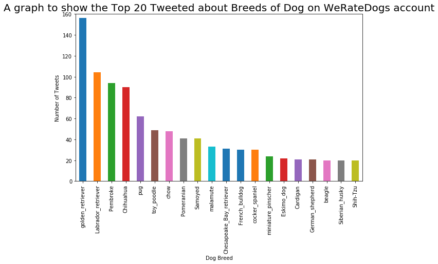

```python
# Plot a bar chart to show top 20 tweeted breeds
fig = plt.figure(figsize=(10,6))
df_breeds['dog_breed'].value_counts().sort_values(ascending=True).nlargest(20).plot(kind='bar')
plt.title("A graph to show the Top 20 Tweeted about Breeds of Dog on WeRateDogs account",fontsize=20)
plt.ylabel("Number of Tweets")
plt.xlabel("Dog Breed");
plt.ylim([0, 160])
```

Checking to make sure all 'Unknown' dog breeds have been removed also answered my first question -

### The most tweeted about dog breed was a Golden Retriever receiving 156 tweets

### 2) Which breed of dog recieved the highest average number of retweets

```python
avg_retweet = df_breeds.groupby(['dog_breed'])['retweets'].mean().sort_values(ascending=False)
avg_retweet.head(10)
```

```
dog_breed
Bedlington_terrier    6982.166667
Afghan_hound          4978.000000
standard_poodle       4669.181818
French_bulldog        4592.733333
English_springer      4579.600000
Saluki                4309.750000
whippet               4284.454545
cocker_spaniel        4129.866667
Eskimo_dog            4047.045455
Samoyed               3962.219512
Name: retweets, dtype: float64
```

```
Text(0,0.5,'Average number of retweets')
```

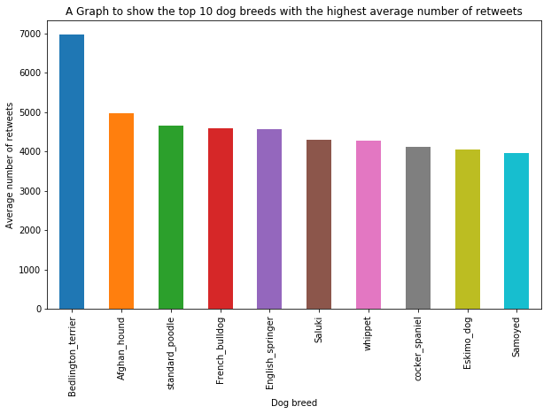

```python
fig = plt.figure(figsize=(10,6))

df_breeds.groupby(['dog_breed'])['retweets'].mean().sort_values(ascending=False).nlargest(10).plot(kind='bar')


plt.title("A Graph to show the top 10 dog breeds with the highest average number of retweets")
plt.xlabel("Dog breed")
plt.ylabel("Average number of retweets")
```

From the data shown above I can say that the breed of dog that received the highest average number of retweets was the Bedlinton Terrier

### 3) Which breed of dog recieved the highest average rating

create average rating column, divide dog_score by out of column. Group by as per Q2. The produce graph for top 10?

```python
df['rating'] = (df['dog_score']) / df['out_of']
df = df[['tweet_id' ,'tweet_date','tweet_source',
           'tweet_text','dog_name','dog_type','dog_breed',
           'probability_calc','no_of_likes','retweets','dog_score',
           'out_of','rating','tweet_link','image_link',]]
df.head()
```

|  | tweet_id | tweet_date | tweet_source | tweet_text | dog_name | dog_type | dog_breed | probability_calc | no_of_likes | retweets | dog_score | out_of | rating | tweet_link | image_link |
| --- | --- | --- | --- | --- | --- | --- | --- | --- | --- | --- | --- | --- | --- | --- | --- |
| 0 | 667435689202614272 | 2015-11-19 20:14:03 | Twitter for iPhone | Ermergerd 12/10 https://t.co/PQni2sjPsm | None | None | Rottweiler | 0.999091 | 283.0 | 79.0 | 12 | 10 | 1.2 | https://twitter.com/dog_rates/status/667435689... | https://pbs.twimg.com/media/CUM1OHCW4AEgGSi.jpg |
| 1 | 667437278097252352 | 2015-11-19 20:20:22 | Twitter for iPhone | Never seen this breed before. Very pointy pup.... | None | None | Unknown | 0.000000 | 410.0 | 213.0 | 10 | 10 | 1.0 | https://twitter.com/dog_rates/status/667437278... | https://pbs.twimg.com/media/CUM2qWaWoAUZ06L.jpg |
| 2 | 667443425659232256 | 2015-11-19 20:44:47 | Twitter for iPhone | Exotic dog here. Long neck. Weird paws. Obsess... | None | None | Unknown | 0.000000 | 710.0 | 525.0 | 6 | 10 | 0.6 | https://twitter.com/dog_rates/status/667443425... | https://pbs.twimg.com/media/CUM8QZwW4AAVsBl.jpg |
| 3 | 667453023279554560 | 2015-11-19 21:22:56 | Twitter Web Client | Meet Cupcake. I would do unspeakable things fo... | Cupcake | None | Labrador_retriever | 0.825670 | 291.0 | 80.0 | 11 | 10 | 1.1 | https://twitter.com/dog_rates/status/667453023... | https://pbs.twimg.com/media/CUNE_OSUwAAdHhX.jpg |
| 4 | 667455448082227200 | 2015-11-19 21:32:34 | Twitter Web Client | This is Reese and Twips. Reese protects Twips.... | Reese | None | Tibetan_terrier | 0.676376 | 178.0 | 56.0 | 7 | 10 | 0.7 | https://twitter.com/dog_rates/status/667455448... | https://pbs.twimg.com/media/CUNHMXTU8AAS3HH.jpg |

```python
df_breeds = df.query('dog_breed != "Unknown"')

avg_rating = df_breeds.groupby(['dog_breed'])['rating'].mean().sort_values(ascending=False)
avg_rating.head(10)
```

```
dog_breed
Bouvier_des_Flandres    1.300000
Pomeranian              1.253659
Saluki                  1.250000
briard                  1.233333
Tibetan_mastiff         1.225000
Border_terrier          1.214286
standard_schnauzer      1.200000
silky_terrier           1.200000
Gordon_setter           1.175000
Irish_setter            1.175000
Name: rating, dtype: float64
```

```
(1.17, 1.31)
```

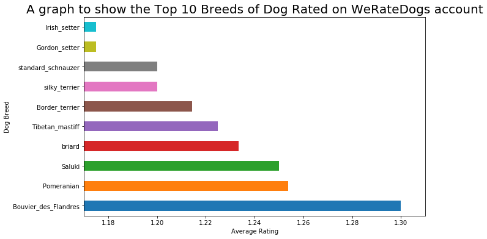

```python
# Plot a horizontal bar chart to show top 10 breeds
fig = plt.figure(figsize=(10,6))
df_breeds.groupby('dog_breed').mean()['rating'].nlargest(10).plot(kind='barh')
plt.title("A graph to show the Top 10 Breeds of Dog Rated on WeRateDogs account",fontsize=20)
plt.ylabel("Dog Breed")
plt.xlabel("Average Rating");
plt.xlim([1.17, 1.31])
```

```python
# Create a variable that includes dog breeds with more than 9 counts
count = df['dog_breed'].value_counts()
```

```python
# Create a new dataframe which includes only dog breeds with at least 10 ratings
avg_rating2 = df_breeds[df_breeds['dog_breed'].isin(count[count > 9].index)]
avg_rating2
```

|  | tweet_id | tweet_date | tweet_source | tweet_text | dog_name | dog_type | dog_breed | probability_calc | no_of_likes | retweets | dog_score | out_of | rating | tweet_link | image_link |
| --- | --- | --- | --- | --- | --- | --- | --- | --- | --- | --- | --- | --- | --- | --- | --- |
| 0 | 667435689202614272 | 2015-11-19 20:14:03 | Twitter for iPhone | Ermergerd 12/10 https://t.co/PQni2sjPsm | None | None | Rottweiler | 0.999091 | 283.0 | 79.0 | 12 | 10 | 1.2 | https://twitter.com/dog_rates/status/667435689... | https://pbs.twimg.com/media/CUM1OHCW4AEgGSi.jpg |
| 3 | 667453023279554560 | 2015-11-19 21:22:56 | Twitter Web Client | Meet Cupcake. I would do unspeakable things fo... | Cupcake | None | Labrador_retriever | 0.825670 | 291.0 | 80.0 | 11 | 10 | 1.1 | https://twitter.com/dog_rates/status/667453023... | https://pbs.twimg.com/media/CUNE_OSUwAAdHhX.jpg |
| 5 | 667470559035432960 | 2015-11-19 22:32:36 | Twitter Web Client | This is a northern Wahoo named Kohl. He runs t... | None | None | toy_poodle | 0.304175 | 231.0 | 88.0 | 11 | 10 | 1.1 | https://twitter.com/dog_rates/status/667470559... | https://pbs.twimg.com/media/CUNU78YWEAECmpB.jpg |
| 6 | 667491009379606528 | 2015-11-19 23:53:52 | Twitter Web Client | Two dogs in this one. Both are rare Jujitsu Py... | None | None | borzoi | 0.852088 | 476.0 | 204.0 | 7 | 10 | 0.7 | https://twitter.com/dog_rates/status/667491009... | https://pbs.twimg.com/media/CUNniSlUYAEj1Jl.jpg |
| 7 | 667495797102141441 | 2015-11-20 00:12:54 | Twitter Web Client | This is Philippe from Soviet Russia. Commandin... | Philippe | None | Chihuahua | 0.143957 | 478.0 | 241.0 | 9 | 10 | 0.9 | https://twitter.com/dog_rates/status/667495797... | https://pbs.twimg.com/media/CUNr4-7UwAAg2lq.jpg |
| 8 | 667502640335572993 | 2015-11-20 00:40:05 | Twitter Web Client | Say hello to Hall and Oates. Oates is winking ... | Hall | None | Labrador_retriever | 0.996709 | 501.0 | 201.0 | 11 | 10 | 1.1 | https://twitter.com/dog_rates/status/667502640... | https://pbs.twimg.com/media/CUNyHTMUYAAQVch.jpg |
| 9 | 667509364010450944 | 2015-11-20 01:06:48 | Twitter Web Client | This a Norwegian Pewterschmidt named Tickles. ... | None | None | beagle | 0.636169 | 6284.0 | 1934.0 | 12 | 10 | 1.2 | https://twitter.com/dog_rates/status/667509364... | https://pbs.twimg.com/media/CUN4Or5UAAAa5K4.jpg |
| 10 | 667517642048163840 | 2015-11-20 01:39:42 | Twitter Web Client | This is Dook &amp; Milo. Dook is struggling to... | Dook | None | Italian_greyhound | 0.125176 | 340.0 | 176.0 | 8 | 10 | 0.8 | https://twitter.com/dog_rates/status/667517642... | https://pbs.twimg.com/media/CUN_wiBUkAAakT0.jpg |
| 11 | 667524857454854144 | 2015-11-20 02:08:22 | Twitter Web Client | Another topnotch dog. His name is Big Jumpy Ra... | None | None | Chesapeake_Bay_retriever | 0.088122 | 1561.0 | 1019.0 | 12 | 10 | 1.2 | https://twitter.com/dog_rates/status/667524857... | https://pbs.twimg.com/media/CUOGUfJW4AA_eni.jpg |
| 13 | 667530908589760512 | 2015-11-20 02:32:25 | Twitter Web Client | Meet Naphaniel. He doesn't necessarily enjoy h... | Naphaniel | None | golden_retriever | 0.633037 | 430.0 | 218.0 | 10 | 10 | 1.0 | https://twitter.com/dog_rates/status/667530908... | https://pbs.twimg.com/media/CUOL0uGUkAAx7yh.jpg |
| 14 | 667538891197542400 | 2015-11-20 03:04:08 | Twitter Web Client | This is a southwest Coriander named Klint. Hat... | None | None | Yorkshire_terrier | 0.618957 | 187.0 | 59.0 | 9 | 10 | 0.9 | https://twitter.com/dog_rates/status/667538891... | https://pbs.twimg.com/media/CUOTFZOW4AABsfW.jpg |
| 15 | 667544320556335104 | 2015-11-20 03:25:43 | Twitter Web Client | This is Kial. Kial is either wearing a cape, w... | Kial | None | Pomeranian | 0.412893 | 787.0 | 482.0 | 10 | 10 | 1.0 | https://twitter.com/dog_rates/status/667544320... | https://pbs.twimg.com/media/CUOYBbbWIAAXQGU.jpg |
| 16 | 667546741521195010 | 2015-11-20 03:35:20 | Twitter Web Client | Here is George. George took a selfie of his ne... | George | None | toy_poodle | 0.787424 | 313.0 | 115.0 | 9 | 10 | 0.9 | https://twitter.com/dog_rates/status/667546741... | https://pbs.twimg.com/media/CUOaOWXWcAA0_Jy.jpg |
| 19 | 667728196545200128 | 2015-11-20 15:36:22 | Twitter Web Client | Meet Olive. He comes to spot by tree to remini... | Olive | None | kuvasz | 0.360159 | 343.0 | 138.0 | 11 | 10 | 1.1 | https://twitter.com/dog_rates/status/667728196... | https://pbs.twimg.com/media/CUQ_QahUAAAVQjn.jpg |
| 21 | 667773195014021121 | 2015-11-20 18:35:10 | Twitter Web Client | This is a rare Hungarian Pinot named Jessiga. ... | None | None | West_Highland_white_terrier | 0.360465 | 213.0 | 47.0 | 8 | 10 | 0.8 | https://twitter.com/dog_rates/status/667773195... | https://pbs.twimg.com/media/CURoLrOVEAAaWdR.jpg |
| 23 | 667793409583771648 | 2015-11-20 19:55:30 | Twitter for iPhone | Dogs only please. Small cows and other non can... | None | None | dalmatian | 0.535073 | 639.0 | 303.0 | 8 | 10 | 0.8 | https://twitter.com/dog_rates/status/667793409... | https://pbs.twimg.com/media/CUR6jqVWsAEgGot.jpg |
| 25 | 667806454573760512 | 2015-11-20 20:47:20 | Twitter for iPhone | This is Filup. He is overcome with joy after f... | Filup | None | Chihuahua | 0.187155 | 972.0 | 447.0 | 10 | 10 | 1.0 | https://twitter.com/dog_rates/status/667806454... | https://pbs.twimg.com/media/CUSGbXeVAAAgztZ.jpg |
| 26 | 667534815156183040 | 2015-11-20 02:47:56 | Twitter Web Client | This is Frank (pronounced "Fronq"). Too many b... | Frank | None | Pembroke | 0.435254 | 749.0 | 479.0 | 8 | 10 | 0.8 | https://twitter.com/dog_rates/status/667534815... | https://pbs.twimg.com/media/CUOPYI5UcAAj_nO.jpg |
| 29 | 667211855547486208 | 2015-11-19 05:24:37 | Twitter for iPhone | This is Genevieve. She is a golden retriever c... | Genevieve | None | golden_retriever | 0.462556 | 445.0 | 220.0 | 9 | 10 | 0.9 | https://twitter.com/dog_rates/status/667211855... | https://pbs.twimg.com/media/CUJppKJWoAA75NP.jpg |
| 33 | 666826780179869698 | 2015-11-18 03:54:28 | Twitter for iPhone | 12/10 simply brilliant pup https://t.co/V6ZzG4... | None | None | Maltese_dog | 0.359383 | 233.0 | 81.0 | 12 | 10 | 1.2 | https://twitter.com/dog_rates/status/666826780... | https://pbs.twimg.com/media/CUELa0NUkAAscGC.jpg |
| 34 | 666835007768551424 | 2015-11-18 04:27:09 | Twitter for iPhone | These are Peruvian Feldspars. Their names are ... | None | None | Airedale | 0.448459 | 190.0 | 71.0 | 10 | 10 | 1.0 | https://twitter.com/dog_rates/status/666835007... | https://pbs.twimg.com/media/CUES51dXIAEahyG.jpg |
| 37 | 666996132027977728 | 2015-11-18 15:07:24 | Twitter for iPhone | This is Carll. He wants to be a donkey. But al... | Carll | None | Rottweiler | 0.062490 | 222.0 | 80.0 | 10 | 10 | 1.0 | https://twitter.com/dog_rates/status/666996132... | https://pbs.twimg.com/media/CUGlb6iUwAITEbW.jpg |
| 39 | 667044094246576128 | 2015-11-18 18:17:59 | Twitter for iPhone | 12/10 gimme now https://t.co/QZAnwgnOMB | None | None | golden_retriever | 0.765266 | 172.0 | 44.0 | 12 | 10 | 1.2 | https://twitter.com/dog_rates/status/667044094... | https://pbs.twimg.com/media/CUHREBXXAAE6A9b.jpg |
| 40 | 667062181243039745 | 2015-11-18 19:29:52 | Twitter for iPhone | This is Keet. He is a Floridian Amukamara. Abs... | Keet | None | Chesapeake_Bay_retriever | 0.825678 | 201.0 | 47.0 | 10 | 10 | 1.0 | https://twitter.com/dog_rates/status/667062181... | https://pbs.twimg.com/media/CUHhgvHUAAA4aB0.jpg |
| 42 | 667073648344346624 | 2015-11-18 20:15:26 | Twitter for iPhone | Here is Dave. He is actually just a skinny leg... | Dave | None | Chihuahua | 0.483682 | 368.0 | 106.0 | 10 | 10 | 1.0 | https://twitter.com/dog_rates/status/667073648... | https://pbs.twimg.com/media/CUHr8WbWEAEBPgf.jpg |
| 43 | 667090893657276420 | 2015-11-18 21:23:57 | Twitter for iPhone | This is Clybe. He is an Anemone Valdez. One ea... | Clybe | None | Chihuahua | 0.959514 | 304.0 | 112.0 | 7 | 10 | 0.7 | https://twitter.com/dog_rates/status/667090893... | https://pbs.twimg.com/media/CUH7oLuUsAELWib.jpg |
| 44 | 667119796878725120 | 2015-11-18 23:18:48 | Twitter for iPhone | This is Gabe. He is a southern Baklava. Gabe h... | Gabe | None | Pembroke | 0.741563 | 301.0 | 118.0 | 10 | 10 | 1.0 | https://twitter.com/dog_rates/status/667119796... | https://pbs.twimg.com/media/CUIV6F7XIAA1tAM.jpg |
| 45 | 667138269671505920 | 2015-11-19 00:32:12 | Twitter for iPhone | Extremely intelligent dog here. Has learned to... | None | None | West_Highland_white_terrier | 0.747713 | 4175.0 | 1968.0 | 10 | 10 | 1.0 | https://twitter.com/dog_rates/status/667138269... | https://pbs.twimg.com/media/CUImtzEVAAAZNJo.jpg |
| 46 | 667152164079423490 | 2015-11-19 01:27:25 | Twitter for iPhone | This is Pipsy. He is a fluffball. Enjoys trave... | Pipsy | None | toy_poodle | 0.535411 | 43779.0 | 15229.0 | 12 | 10 | 1.2 | https://twitter.com/dog_rates/status/667152164... | https://pbs.twimg.com/media/CUIzWk_UwAAfUNq.jpg |
| 47 | 667160273090932737 | 2015-11-19 01:59:39 | Twitter for iPhone | This is Bradlay. He is a Ronaldinho Matsuyama ... | Bradlay | None | golden_retriever | 0.471351 | 232.0 | 55.0 | 11 | 10 | 1.1 | https://twitter.com/dog_rates/status/667160273... | https://pbs.twimg.com/media/CUI6uuaW4AAvCIs.jpg |
| 48 | 667165590075940865 | 2015-11-19 02:20:46 | Twitter for iPhone | This is Churlie. AKA Fetty Woof. Lost eye savi... | Churlie | None | miniature_pinscher | 0.140173 | 2469.0 | 1022.0 | 10 | 10 | 1.0 | https://twitter.com/dog_rates/status/667165590... | https://pbs.twimg.com/media/CUI_kHBWsAAAef5.jpg |
| 50 | 667174963120574464 | 2015-11-19 02:58:01 | Twitter for iPhone | This is Clarence. His face says he doesn't wan... | Clarence | None | toy_poodle | 0.266437 | 226.0 | 71.0 | 9 | 10 | 0.9 | https://twitter.com/dog_rates/status/667174963... | https://pbs.twimg.com/media/CUJIFoJWsAAL3Dc.jpg |
| 51 | 667176164155375616 | 2015-11-19 03:02:47 | Twitter for iPhone | These are strange dogs. All have toupees. Long... | None | None | soft-coated_wheaten_terrier | 0.318981 | 552.0 | 413.0 | 4 | 10 | 0.4 | https://twitter.com/dog_rates/status/667176164... | https://pbs.twimg.com/media/CUJJLtWWsAE-go5.jpg |
| 52 | 667177989038297088 | 2015-11-19 03:10:02 | Twitter for iPhone | This is a Dasani Kingfisher from Maine. His na... | None | None | vizsla | 0.259249 | 176.0 | 50.0 | 8 | 10 | 0.8 | https://twitter.com/dog_rates/status/667177989... | https://pbs.twimg.com/media/CUJK18UWEAEg7AR.jpg |
| 53 | 667182792070062081 | 2015-11-19 03:29:07 | Twitter for iPhone | This is Timison. He just told an awful joke bu... | Timison | None | golden_retriever | 0.949892 | 13082.0 | 5541.0 | 10 | 10 | 1.0 | https://twitter.com/dog_rates/status/667182792... | https://pbs.twimg.com/media/CUJPNjOWsAAZRqP.jpg |
| 55 | 667192066997374976 | 2015-11-19 04:05:59 | Twitter for iPhone | *takes several long deep breaths* omg omg oMG ... | None | None | Rottweiler | 0.283640 | 350.0 | 88.0 | 12 | 10 | 1.2 | https://twitter.com/dog_rates/status/667192066... | https://pbs.twimg.com/media/CUJXpRBXIAAN0yz.jpg |
| 56 | 667200525029539841 | 2015-11-19 04:39:35 | Twitter for iPhone | This is Joshwa. He is a fuckboy supreme. He cl... | Joshwa | None | Siberian_husky | 0.694904 | 569.0 | 237.0 | 11 | 10 | 1.1 | https://twitter.com/dog_rates/status/667200525... | https://pbs.twimg.com/media/CUJfVMPXIAAgbue.jpg |
| ... | ... | ... | ... | ... | ... | ... | ... | ... | ... | ... | ... | ... | ... | ... | ... |
| 1923 | 750383411068534784 | 2016-07-05 17:38:41 | Twitter for iPhone | This is Zoe. She was trying to stealthily take... | Zoe | pupper | Border_collie | 0.672791 | 4400.0 | 1093.0 | 9 | 10 | 0.9 | https://twitter.com/dog_rates/status/750383411... | https://pbs.twimg.com/media/CmnluwbXEAAqnkw.jpg |
| 1924 | 676575501977128964 | 2015-12-15 01:32:24 | Twitter for iPhone | This pupper is very passionate about Christmas... | None | pupper | Yorkshire_terrier | 0.073144 | 2423.0 | 1047.0 | 8 | 10 | 0.8 | https://twitter.com/dog_rates/status/676575501... | https://pbs.twimg.com/media/CWOt07EUsAAnOYW.jpg |
| 1925 | 866450705531457537 | 2017-05-22 00:28:40 | Twitter for iPhone | This is Jamesy. He gives a kiss to every other... | Jamesy | pupper | French_bulldog | 0.905334 | 112452.0 | 31506.0 | 13 | 10 | 1.3 | https://twitter.com/dog_rates/status/866450705... | https://pbs.twimg.com/media/DAZAUfBXcAAG_Nn.jpg |
| 1927 | 750868782890057730 | 2016-07-07 01:47:22 | Twitter for iPhone | Meet Milo. He hauled ass until he ran out of t... | Milo | pupper | toy_poodle | 0.912648 | 4612.0 | 1305.0 | 11 | 10 | 1.1 | https://twitter.com/dog_rates/status/750868782... | https://pbs.twimg.com/media/CmufLLsXYAAsU0r.jpg |
| 1928 | 672205392827572224 | 2015-12-03 00:07:09 | Twitter for iPhone | This is Opal. He's a Royal John Coctostan. Rea... | Opal | pupper | pug | 0.003267 | 2081.0 | 1047.0 | 9 | 10 | 0.9 | https://twitter.com/dog_rates/status/672205392... | https://pbs.twimg.com/media/CVQnPMrVAAAzShR.jpg |
| 1929 | 676470639084101634 | 2015-12-14 18:35:43 | Twitter for iPhone | Three generations of pupper. 11/10 for all htt... | None | pupper | golden_retriever | 0.790386 | 10971.0 | 4373.0 | 11 | 10 | 1.1 | https://twitter.com/dog_rates/status/676470639... | https://pbs.twimg.com/media/CWNOdIpWoAAWid2.jpg |
| 1930 | 751456908746354688 | 2016-07-08 16:44:23 | Twitter for iPhone | Here's a pupper that's very hungry but too laz... | None | pupper | golden_retriever | 0.714409 | 3104.0 | 960.0 | 12 | 10 | 1.2 | https://twitter.com/dog_rates/status/751456908... | https://pbs.twimg.com/ext_tw_video_thumb/75145... |
| 1931 | 773547596996571136 | 2016-09-07 15:44:53 | Twitter for iPhone | This is Chelsea. She forgot how to dog. 11/10 ... | Chelsea | pupper | Norwegian_elkhound | 0.372202 | 21553.0 | 5934.0 | 11 | 10 | 1.1 | https://twitter.com/dog_rates/status/773547596... | https://pbs.twimg.com/media/Crwxb5yWgAAX5P_.jpg |
| 1932 | 672254177670729728 | 2015-12-03 03:21:00 | Twitter for iPhone | This is Rolf. He's having the time of his life... | Rolf | pupper | pug | 0.979487 | 1326.0 | 681.0 | 11 | 10 | 1.1 | https://twitter.com/dog_rates/status/672254177... | https://pbs.twimg.com/media/CVRTmz1WcAA4uMF.jpg |
| 1933 | 672160042234327040 | 2015-12-02 21:06:56 | Twitter for iPhone | This is Bubba. He's a Titted Peebles Aorta. Ev... | Bubba | pupper | pug | 0.561027 | 810.0 | 326.0 | 8 | 10 | 0.8 | https://twitter.com/dog_rates/status/672160042... | https://pbs.twimg.com/media/CVP9_beUEAAwURR.jpg |
| 1934 | 676617503762681856 | 2015-12-15 04:19:18 | Twitter for iPhone | I promise this wasn't meant to be a cuteness o... | None | pupper | Chihuahua | 0.841084 | 2714.0 | 892.0 | 13 | 10 | 1.3 | https://twitter.com/dog_rates/status/676617503... | https://pbs.twimg.com/media/CWPUB9TWwAALPPx.jpg |
| 1935 | 700143752053182464 | 2016-02-18 02:24:13 | Twitter for iPhone | When it's Janet from accounting's birthday but... | None | pupper | golden_retriever | 0.532460 | 7204.0 | 2578.0 | 10 | 10 | 1.0 | https://twitter.com/dog_rates/status/700143752... | https://pbs.twimg.com/media/CbdpBmLUYAY9SgQ.jpg |
| 1936 | 676819651066732545 | 2015-12-15 17:42:34 | Twitter for iPhone | Watch out Airbud. This pupper is also good at ... | None | pupper | Labrador_retriever | 0.039465 | 1722.0 | 619.0 | 12 | 10 | 1.2 | https://twitter.com/dog_rates/status/676819651... | https://pbs.twimg.com/media/CWSL4W8WsAAE4KU.jpg |
| 1937 | 676936541936185344 | 2015-12-16 01:27:03 | Twitter for iPhone | Here we see a rare pouched pupper. Ample stora... | None | pupper | Chesapeake_Bay_retriever | 0.545286 | 12041.0 | 4643.0 | 8 | 10 | 0.8 | https://twitter.com/dog_rates/status/676936541... | https://pbs.twimg.com/media/CWT2MUgWIAECWig.jpg |
| 1939 | 699036661657767936 | 2016-02-15 01:05:02 | Twitter for iPhone | HAPPY V-DAY FROM YOUR FAV PUPPER SQUAD 13/10 f... | None | pupper | Chihuahua | 0.222943 | 2500.0 | 1148.0 | 13 | 10 | 1.3 | https://twitter.com/dog_rates/status/699036661... | https://pbs.twimg.com/media/CbN6IW4UYAAyVDA.jpg |
| 1940 | 687312378585812992 | 2016-01-13 16:36:55 | Twitter for iPhone | "You got any games on your phone" 7/10 for inv... | None | pupper | Great_Dane | 0.139909 | 4182.0 | 1808.0 | 7 | 10 | 0.7 | https://twitter.com/dog_rates/status/687312378... | https://pbs.twimg.com/media/CYnS9VWW8AAeR8m.jpg |
| 1941 | 751132876104687617 | 2016-07-07 19:16:47 | Twitter for iPhone | This is Cooper. He's just so damn happy. 10/10... | Cooper | puppo | Labrador_retriever | 0.929390 | 4890.0 | 1244.0 | 10 | 10 | 1.0 | https://twitter.com/dog_rates/status/751132876... | https://pbs.twimg.com/media/CmyPXNOW8AEtaJ-.jpg |
| 1943 | 822872901745569793 | 2017-01-21 18:26:02 | Twitter for iPhone | Here's a super supportive puppo participating ... | None | puppo | Lakeland_terrier | 0.196015 | 128364.0 | 41715.0 | 13 | 10 | 1.3 | https://twitter.com/dog_rates/status/822872901... | https://pbs.twimg.com/media/C2tugXLXgAArJO4.jpg |
| 1944 | 802239329049477120 | 2016-11-25 19:55:35 | Twitter for iPhone | This is Loki. He'll do your taxes for you. Can... | Loki | puppo | Eskimo_dog | 0.482498 | 8946.0 | 2566.0 | 12 | 10 | 1.2 | https://twitter.com/dog_rates/status/802239329... | https://pbs.twimg.com/media/CyIgaTEVEAA-9zS.jpg |
| 1945 | 859607811541651456 | 2017-05-03 03:17:27 | Twitter for iPhone | Sorry for the lack of posts today. I came home... | None | puppo | golden_retriever | 0.895529 | 17361.0 | 1407.0 | 13 | 10 | 1.3 | https://twitter.com/dog_rates/status/859607811... | https://pbs.twimg.com/media/C-3wvtxXcAUTuBE.jpg |
| 1946 | 752519690950500352 | 2016-07-11 15:07:30 | Twitter for iPhone | Hopefully this puppo on a swing will help get ... | None | puppo | Labrador_retriever | 0.000010 | 7111.0 | 3298.0 | 11 | 10 | 1.1 | https://twitter.com/dog_rates/status/752519690... | https://pbs.twimg.com/media/CnF8qVDWYAAh0g1.jpg |
| 1948 | 744995568523612160 | 2016-06-20 20:49:19 | Twitter for iPhone | This is Abby. She got her face stuck in a glas... | Abby | puppo | Old_English_sheepdog | 0.427481 | 2849.0 | 586.0 | 9 | 10 | 0.9 | https://twitter.com/dog_rates/status/744995568... | https://pbs.twimg.com/media/ClbBg4WWEAMjwJu.jpg |
| 1949 | 790946055508652032 | 2016-10-25 16:00:09 | Twitter for iPhone | This is Betty. She's assisting with the dishes... | Betty | puppo | golden_retriever | 0.245773 | 16387.0 | 4570.0 | 12 | 10 | 1.2 | https://twitter.com/dog_rates/status/790946055... | https://pbs.twimg.com/media/CvoBPWRWgAA4het.jpg |
| 1950 | 819952236453363712 | 2017-01-13 17:00:21 | Twitter for iPhone | This is Oliver. He has dreams of being a servi... | Oliver | puppo | American_Staffordshire_terrier | 0.925505 | 5196.0 | 1135.0 | 13 | 10 | 1.3 | https://www.gofundme.com/servicedogoliver,http... | https://pbs.twimg.com/media/C2EONHNWQAUWxkP.jpg |
| 1951 | 878776093423087618 | 2017-06-25 00:45:22 | Twitter for iPhone | This is Snoopy. He's a proud #PrideMonthPuppo.... | Snoopy | puppo | Italian_greyhound | 0.734684 | 17650.0 | 3588.0 | 13 | 10 | 1.3 | https://twitter.com/dog_rates/status/878776093... | https://pbs.twimg.com/media/DDIKMXzW0AEibje.jpg |
| 1952 | 889665388333682689 | 2017-07-25 01:55:32 | Twitter for iPhone | Here's a puppo that seems to be on the fence a... | None | puppo | Pembroke | 0.966327 | 43467.0 | 8703.0 | 13 | 10 | 1.3 | https://twitter.com/dog_rates/status/889665388... | https://pbs.twimg.com/media/DFi579UWsAAatzw.jpg |
| 1953 | 743253157753532416 | 2016-06-16 01:25:36 | Twitter for iPhone | This is Kilo. He cannot reach the snackum. Nif... | Kilo | puppo | malamute | 0.442612 | 4070.0 | 1169.0 | 10 | 10 | 1.0 | https://twitter.com/dog_rates/status/743253157... | https://pbs.twimg.com/media/ClCQzFUUYAA5vAu.jpg |
| 1954 | 889531135344209921 | 2017-07-24 17:02:04 | Twitter for iPhone | This is Stuart. He's sporting his favorite fan... | Stuart | puppo | golden_retriever | 0.953442 | 13770.0 | 1961.0 | 13 | 10 | 1.3 | https://twitter.com/dog_rates/status/889531135... | https://pbs.twimg.com/media/DFg_2PVW0AEHN3p.jpg |
| 1955 | 756275833623502848 | 2016-07-21 23:53:04 | Twitter for iPhone | When ur older siblings get to play in the deep... | None | puppo | Airedale | 0.602957 | 6174.0 | 1471.0 | 10 | 10 | 1.0 | https://twitter.com/dog_rates/status/756275833... | https://pbs.twimg.com/media/Cn7U2xlW8AI9Pqp.jpg |
| 1956 | 793195938047070209 | 2016-10-31 21:00:23 | Twitter for iPhone | Say hello to Lily. She's pupset that her costu... | Lily | puppo | Labrador_retriever | 0.654762 | 15001.0 | 5496.0 | 12 | 10 | 1.2 | https://twitter.com/dog_rates/status/793195938... | https://pbs.twimg.com/media/CwH_foYWgAEvTyI.jpg |
| 1957 | 738537504001953792 | 2016-06-03 01:07:16 | Twitter for iPhone | This is Bayley. She fell asleep trying to esca... | Bayley | puppo | chow | 0.808737 | 4873.0 | 1461.0 | 11 | 10 | 1.1 | https://twitter.com/dog_rates/status/738537504... | https://pbs.twimg.com/media/Cj_P7rSUgAAYQbz.jpg |
| 1958 | 825026590719483904 | 2017-01-27 17:04:02 | Twitter for iPhone | Say hello to Pablo. He's one gorgeous puppo. A... | Pablo | puppo | Eskimo_dog | 0.524454 | 6113.0 | 1206.0 | 12 | 10 | 1.2 | https://www.gofundme.com/my-puppys-double-cata... | https://pbs.twimg.com/media/C3MVTeHWcAAGNfx.jpg |
| 1959 | 787717603741622272 | 2016-10-16 18:11:26 | Twitter for iPhone | This is Tonks. She is a service puppo. Can hea... | Tonks | puppo | German_shepherd | 0.992339 | 10083.0 | 2703.0 | 13 | 10 | 1.3 | https://twitter.com/dog_rates/status/787717603... | https://pbs.twimg.com/media/Cu6I9vvWIAAZG0a.jpg |
| 1960 | 803773340896923648 | 2016-11-30 01:31:12 | Twitter for iPhone | This is Diogi. He fell in the pool as soon as ... | Diogi | puppo | miniature_pinscher | 0.817066 | 9896.0 | 2683.0 | 12 | 10 | 1.2 | https://twitter.com/dog_rates/status/803773340... | https://pbs.twimg.com/media/CyeTku-XcAALkBd.jpg |
| 1961 | 874012996292530176 | 2017-06-11 21:18:31 | Twitter for iPhone | This is Sebastian. He can't see all the colors... | Sebastian | puppo | Cardigan | 0.806674 | 31134.0 | 8961.0 | 13 | 10 | 1.3 | https://twitter.com/dog_rates/status/874012996... | https://pbs.twimg.com/media/DCEeLxjXsAAvNSM.jpg |
| 1962 | 867421006826221569 | 2017-05-24 16:44:18 | Twitter for iPhone | This is Shikha. She just watched you drop a sk... | Shikha | puppo | Eskimo_dog | 0.616457 | 14787.0 | 2216.0 | 12 | 10 | 1.2 | https://twitter.com/dog_rates/status/867421006... | https://pbs.twimg.com/media/DAmyy8FXYAIH8Ty.jpg |
| 1963 | 825535076884762624 | 2017-01-29 02:44:34 | Twitter for iPhone | Here's a very loving and accepting puppo. Appe... | None | puppo | Rottweiler | 0.681495 | 55661.0 | 16987.0 | 14 | 10 | 1.4 | https://twitter.com/dog_rates/status/825535076... | https://pbs.twimg.com/media/C3TjvitXAAAI-QH.jpg |

1402 rows × 15 columns

```python
# A summary of average ratings for breeds with 10 or more ratings.
avg_rating2.groupby(['dog_breed'])['rating'].mean().sort_values(ascending=False)
```

```
dog_breed
Pomeranian                        1.253659
Samoyed                           1.173171
golden_retriever                  1.156774
Great_Pyrenees                    1.146667
Pembroke                          1.142553
chow                              1.141667
Eskimo_dog                        1.140909
cocker_spaniel                    1.133333
kelpie                            1.130769
Siberian_husky                    1.130000
Bernese_mountain_dog              1.127273
French_bulldog                    1.116667
Labrador_retriever                1.116346
Cardigan                          1.114286
Blenheim_spaniel                  1.110000
Pekinese                          1.100000
Rottweiler                        1.100000
German_shepherd                   1.100000
toy_poodle                        1.097959
schipperke                        1.092308
Norwegian_elkhound                1.090909
collie                            1.090909
malamute                          1.087879
Old_English_sheepdog              1.085714
vizsla                            1.084615
Chesapeake_Bay_retriever          1.083871
Great_Dane                        1.081818
malinois                          1.081818
standard_poodle                   1.072727
basset                            1.070588
kuvasz                            1.064706
Staffordshire_bullterrier         1.063158
Border_collie                     1.058333
boxer                             1.054545
Chihuahua                         1.053333
English_springer                  1.050000
Shetland_sheepdog                 1.038889
Shih-Tzu                          1.035000
pug                               1.024194
Lakeland_terrier                  1.023529
Yorkshire_terrier                 1.020000
West_Highland_white_terrier       1.018750
whippet                           1.018182
beagle                            1.015000
American_Staffordshire_terrier    1.013333
miniature_pinscher                1.004167
borzoi                            1.000000
Italian_greyhound                 1.000000
Airedale                          0.983333
Maltese_dog                       0.973684
Boston_bull                       0.941667
dalmatian                         0.933333
soft-coated_wheaten_terrier       0.850000
Name: rating, dtype: float64
```

```
(1.12, 1.26)
```

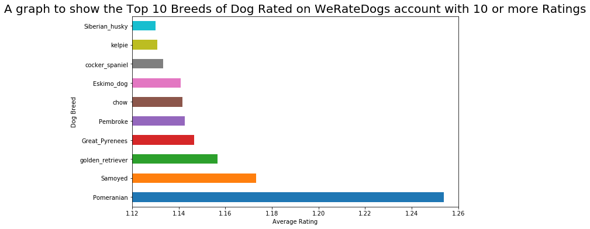

```python
# Plot a horizontal bar chart to show top 10 breeds
fig = plt.figure(figsize=(10,6))
avg_rating2.groupby('dog_breed').mean()['rating'].sort_values(ascending=True).nlargest(10).plot(kind='barh')
plt.title("A graph to show the Top 10 Breeds of Dog Rated on WeRateDogs account with 10 or more Ratings",fontsize=20)
plt.ylabel("Dog Breed")
plt.xlabel("Average Rating");
plt.xlim([1.12, 1.26])
```

From this ratings graph it is clear to see that the Pomeranian received the highest number of average ratings on Twitter. 2nd was the Samoyed and 3rd the Golden Retreiver.

### Sources

Notes taken from Udacity Data Wrangling Course - Notes taken.  
https://pandas.pydata.org/  
https://media.readthedocs.org/pdf/tweepy/latest/tweepy.pdf  
https://www.shanelynn.ie/select-pandas-dataframe-rows-and-columns-using-iloc-loc-and-ix/  
https://stackoverflow.com/questions/28384588/twitter-api-get-tweets-with-specific-id  
https://docs.tweepy.org/en/latest/api.html